# **forecast** Package Crash Course

Mario Annau

November 21, 2016

## Influenza (Google Trends)

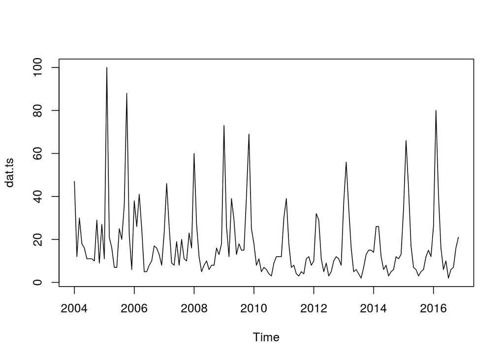

```r
# from https://www.google.com/trends/explore?cat=45&date=all&geo=AT&q=influenza
dat.raw <- read.csv("forecast_intro/Influenza.csv", header = TRUE, skip = 1, stringsAsFactors = FALSE)
dat.ts <- ts(dat.raw[, 2], frequency = 12, start = c(2004, 1))
plot(dat.ts)
```

```r
dat.ts
```

```
##      Jan Feb Mar Apr May Jun Jul Aug Sep Oct Nov Dec
## 2004  47  12  30  18  16  11  11  11  10  29   9  27
## 2005  11 100  21  16   7   7  25  20  36  88  22   6
## 2006  38  26  41  25   5   5   8  10  17  16  13   8
## 2007  23  46  26   9   8  19   8  20  11  10  23  16
## 2008  60  27  12   5   8  10   6   8   8  16  13  18
## 2009  73  26  12  39  29  13  18  15  15  40  69  25
## 2010  18   8  11   5   7   6   4   3   9  12  12  12
## 2011  30  39  18   7   8   4   3   5   4  11  12   8
## 2012  10  32  29  11   5   9   3   5  10  12  11   8
## 2013  37  56  35  16   5   6   4   2   7  13  15  15
## 2014  14  26  26  12   6   8   3   5   6  12  11  13
## 2015  34  66  44  17   7   6   3   5   6  12  15  12
## 2016  26  80  41  16   6  10   2   6   7  16  21
```

The time series can be decomposed into three components: seasonal, trend-cycle and a residual component.

$$y_t = S_t + T_t + E_t$$

If seasonal component depends on absolute level of time series we can also use a multiplicative model
$$y_t = S_t \times T_t \times E_t$$
By taking the logarithm the additive model can be used.

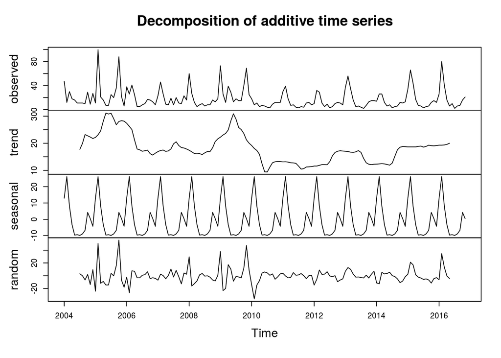

```r
dat.ts.decomp <- decompose(dat.ts, type = "additive")
plot(dat.ts.decomp)
```

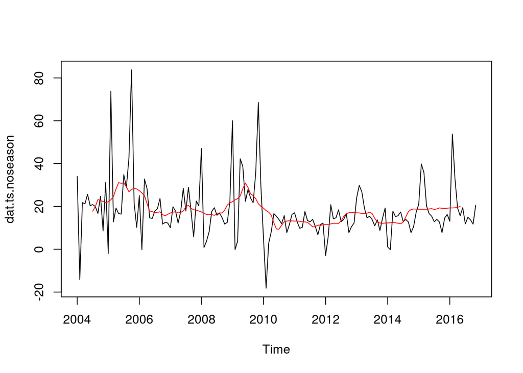

```r
dat.ts.noseason <- dat.ts - dat.ts.decomp$seasonal
plot(dat.ts.noseason)
lines(dat.ts.decomp$trend, col = "red")
```

First we can check if timeseries is stationary. If not clear on plot or unsure, we can use the Augmented Dickey–Fuller Test or Kwiatkowski-Phillips-Schmidt-Shin (KPSS) test

```r
tseries::adf.test(dat.ts, alternative = "stationary")
```

```
##
##  Augmented Dickey-Fuller Test
##
## data:  dat.ts
## Dickey-Fuller = -6.2372, Lag order = 5, p-value = 0.01
## alternative hypothesis: stationary
```

```r
tseries::kpss.test(dat.ts)
```

```
##
##  KPSS Test for Level Stationarity
##
## data:  dat.ts
## KPSS Level = 0.28649, Truncation lag parameter = 2, p-value = 0.1
```

Since no differencing is required, we set
$$d=0$$
and check the acf and pacf plots

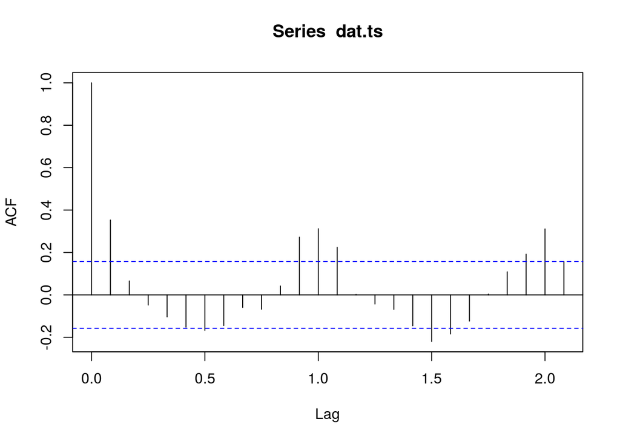

```r
acf(dat.ts, lag.max = 25)
```

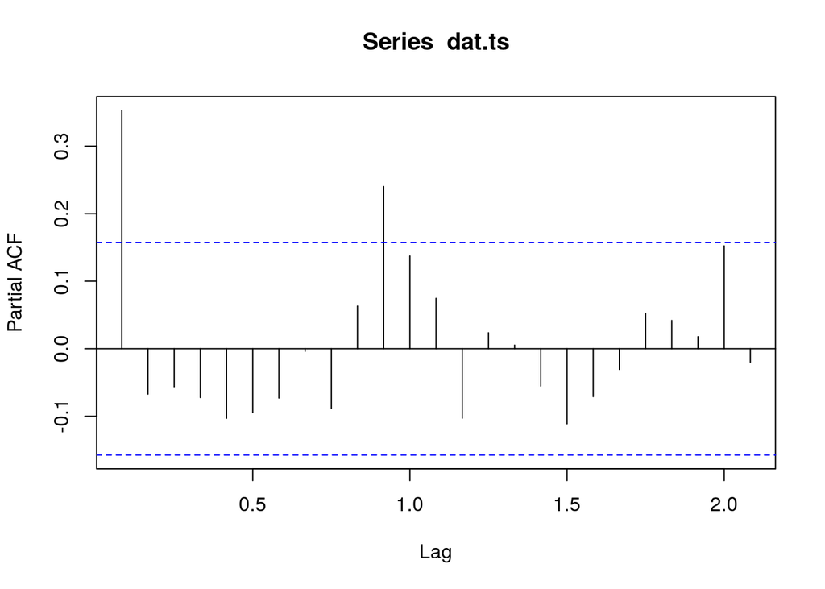

```r
pacf(dat.ts, lag.max = 25)
```

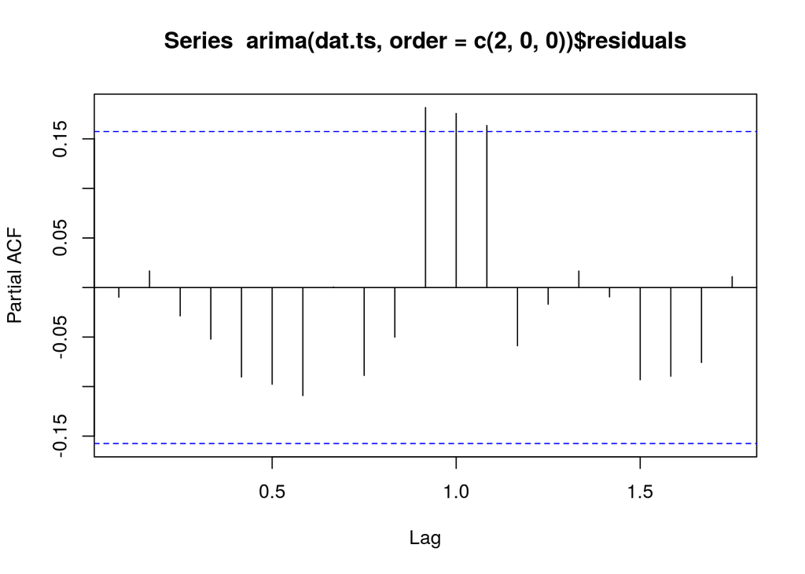

```r
pacf(arima(dat.ts, order= c(2, 0, 0))$residuals)
```

Ups - the pacf plot shows that there is still a seasonal pattern left. We try it with a seasonal order AR of
$$p=1$$

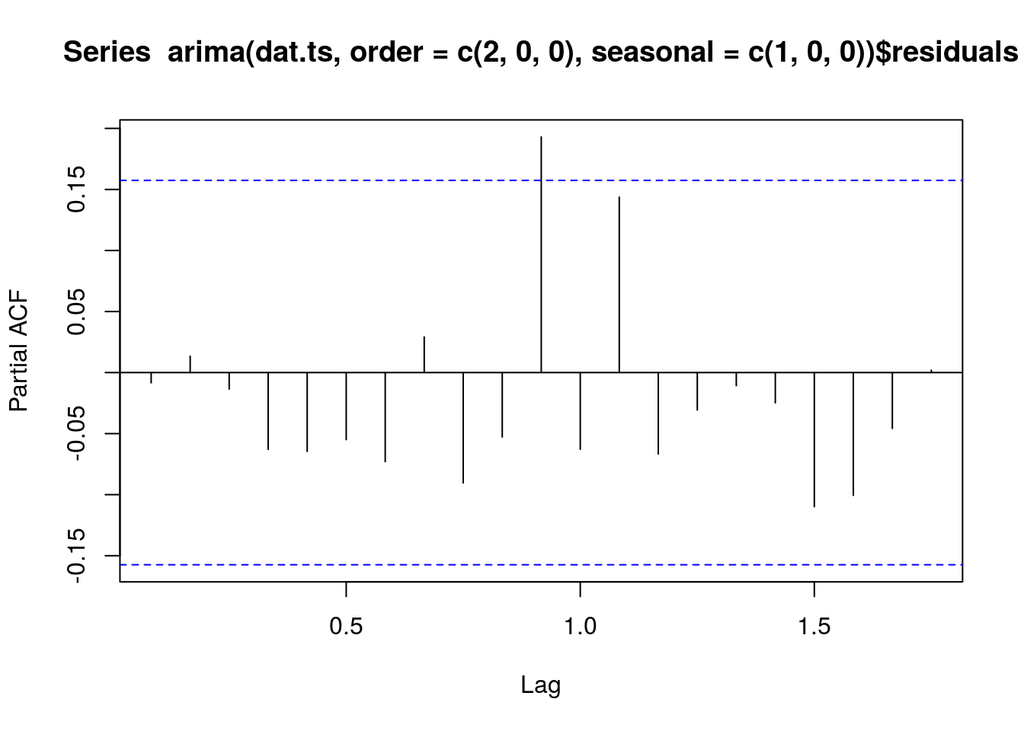

```r
pacf(arima(dat.ts, order= c(2, 0, 0), seasonal = c(1, 0, 0))$residuals)
```

And increase to two since we still have a seasonal effect

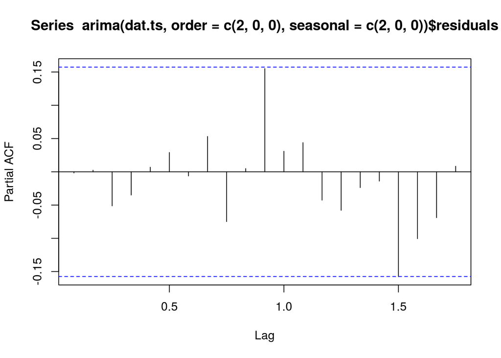

```r
pacf(arima(dat.ts, order= c(2, 0, 0), seasonal = c(2, 0, 0))$residuals)
```

```r
mod1 <- auto.arima(dat.ts)
mod1
```

```
## Series: dat.ts
## ARIMA(1,0,0)(2,0,0)[12] with non-zero mean
##
## Coefficients:
##          ar1    sar1    sar2  intercept
##       0.2520  0.1627  0.3999    19.0788
## s.e.  0.0809  0.0766  0.0932     3.0557
##
## sigma^2 estimated as 211.9:  log likelihood=-635.59
## AIC=1281.19   AICc=1281.59   BIC=1296.4
```

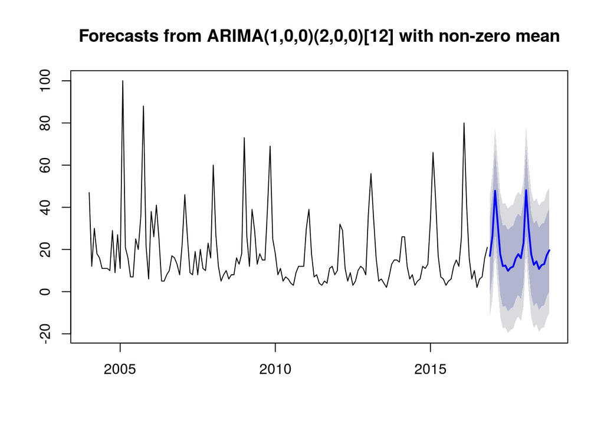

```r
fc <- forecast(mod1, 24)
plot(fc)
```

```r
fc
```

```
##          Point Forecast      Lo 80    Hi 80       Lo 95    Hi 95
## Dec 2016      16.961927 -1.6936941 35.61755 -11.5693834 45.49324
## Jan 2017      26.540975  7.3019416 45.78001  -2.8825873 55.96454
## Feb 2017      47.847228 28.5717309 67.12272  18.3678992 77.32656
## Mar 2017      32.634487 13.3566755 51.91230   3.1516188 62.11735
## Apr 2017      17.752496 -1.5254617 37.03045 -11.7305962 47.23559
## May 2017      12.122195 -7.1557726 31.40016 -17.3609121 41.60530
## Jun 2017      12.372071 -6.9058964 31.65004 -17.1110362 41.85518
## Jul 2017       9.870448 -9.4075204 29.14842 -19.6126602 39.35356
## Aug 2017      11.320984 -7.9569838 30.59895 -18.1621236 40.80409
## Sep 2017      11.883554 -7.3944139 31.16152 -17.5995537 41.36666
## Oct 2017      15.747224 -3.5307440 35.02519 -13.7358837 45.23033
## Nov 2017      17.760418 -1.5175499 37.03839 -11.7226897 47.24353
## Dec 2017      15.903743 -3.6117561 35.41924 -13.9426374 45.75012
## Jan 2018      23.060613  3.5301224 42.59110  -6.8086949 52.92992
## Feb 2018      48.120561 28.5891180 67.65200  18.2497969 77.99132
## Mar 2018      30.050202 10.5186994 49.58171   0.1793462 59.92106
## Apr 2018      17.631869 -1.8996379 37.16338 -12.2389931 47.50273
## May 2018      12.717011 -6.8144965 32.24852 -17.1538518 42.58787
## Jun 2018      14.357157 -5.1743501 33.88866 -15.5137054 44.22802
## Jul 2018      10.751128 -8.7803791 30.28264 -19.1197344 40.62199
## Aug 2018      12.586641 -6.9448662 32.11815 -17.2842216 42.45750
## Sep 2018      13.078052 -6.4534553 32.60956 -16.7928106 42.94891
## Oct 2018      17.305579 -2.2259279 36.83709 -12.5652832 47.17644
## Nov 2018      19.632517  0.1010102 39.16402 -10.2383451 49.50338
```

## Company Data (AMZN)

```r
urls <- paste("http://www.wikinvest.com/stock/Amazon.com_(AMZN)/Data/Revenue", rep(2000:2015, each=4), sprintf("Q%d", 1:4), sep = "/")
vals <- sapply(urls, function(x) {
  tree <- htmlTreeParse(x, useInternalNodes = TRUE)
  xmlValue(getNodeSet(tree, "//div[@id='nv_value']")[[1]])
})
matchvals <- gregexpr("[0-9.]+", vals)
numvals <- as.numeric(sapply(1:length(vals), function(i) substr(vals[i], matchvals[[i]][1], attr(matchvals[[i]], "match.length")[1] + 1)))
numvals <- ifelse(grepl("billion", vals), numvals * 1000, numvals)
amzn.rev <- ts(numvals, start = c(2000, 1), frequency = 4)
```

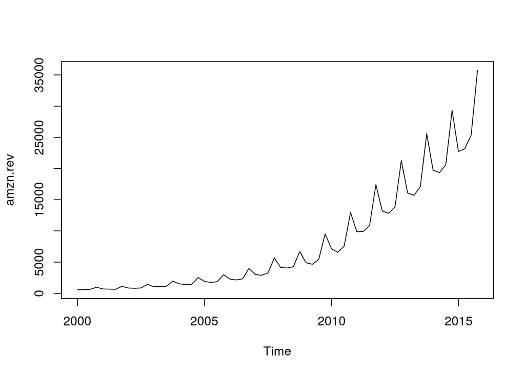

```r
plot(amzn.rev)
```

We can easily see that should 1. Use the log scale or 2. Differentiate the series.

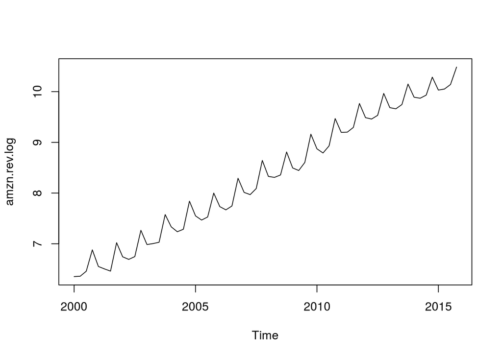

```r
amzn.rev.log <- log(amzn.rev)
plot(amzn.rev.log)
```

Now it’s easy to see the trend and the seasonal component. We are now lazy and use auto.arima again:

```r
mod2 <- auto.arima(amzn.rev.log)
mod2
```

```
## Series: amzn.rev.log
## ARIMA(1,0,0)(2,1,0)[4] with drift
##
## Coefficients:
##          ar1     sar1     sar2   drift
##       0.8721  -0.5769  -0.2558  0.0597
## s.e.  0.0692   0.1473   0.1417  0.0058
##
## sigma^2 estimated as 0.002051:  log likelihood=101.54
## AIC=-193.09   AICc=-191.98   BIC=-182.61
```

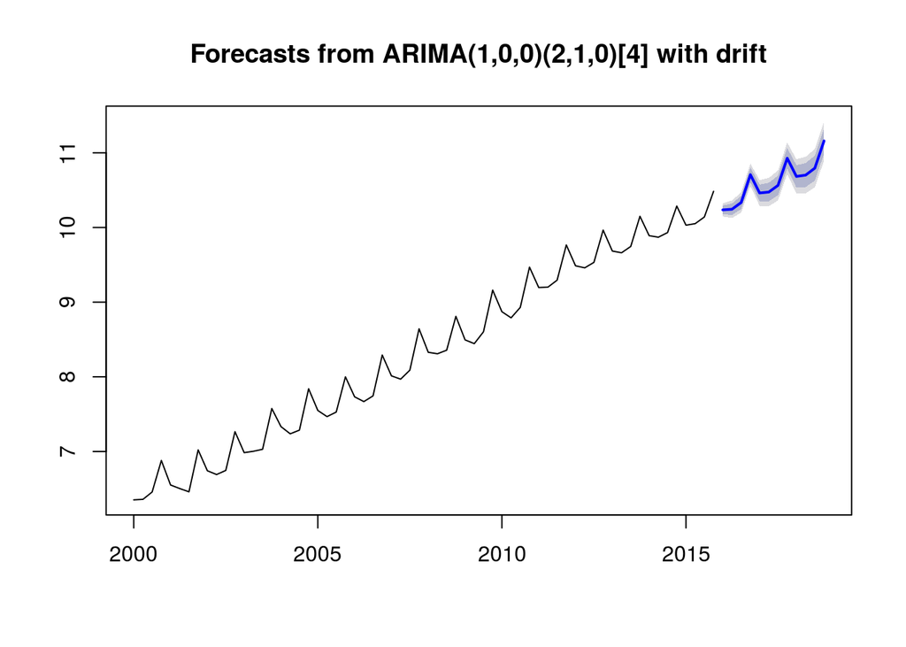

```r
plot(forecast(mod2, 12))
```

```r
mod3 <- auto.arima(amzn.rev)
mod3
```

```
## Series: amzn.rev
## ARIMA(0,1,0)(2,1,0)[4]
##
## Coefficients:
##         sar1    sar2
##       0.2688  0.5529
## s.e.  0.1211  0.1226
##
## sigma^2 estimated as 149679:  log likelihood=-436.59
## AIC=879.17   AICc=879.61   BIC=885.4
```

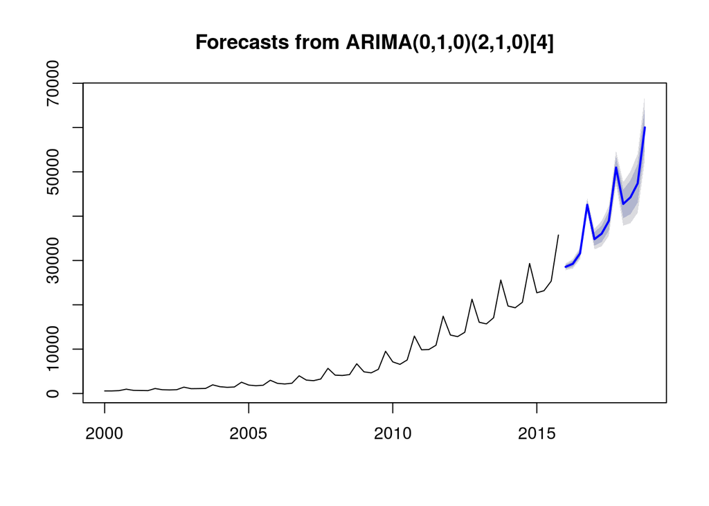

```r
fc3 <- forecast(mod3, 12)
plot(fc3)
```

```r
fc3
```

```
##         Point Forecast    Lo 80    Hi 80    Lo 95    Hi 95
## 2016 Q1       28576.30 28080.49 29072.12 27818.03 29334.58
## 2016 Q2       29263.61 28562.42 29964.79 28191.24 30335.98
## 2016 Q3       31600.70 30741.93 32459.47 30287.32 32914.07
## 2016 Q4       42569.82 41578.19 43561.44 41053.26 44086.37
## 2017 Q1       34824.38 33324.80 36323.97 32530.96 37117.80
## 2017 Q2       36051.12 34176.50 37925.74 33184.14 38918.10
## 2017 Q3       38947.31 36761.07 41133.55 35603.75 42290.88
## 2017 Q4       50978.86 48520.18 53437.53 47218.64 54739.08
## 2018 Q1       42768.06 39557.90 45978.22 37858.54 47677.57
## 2018 Q2       44259.96 40443.53 48076.39 38423.23 50096.69
## 2018 Q3       47398.85 43060.04 51737.65 40763.22 54034.47
## 2018 Q4       60036.20 55231.49 64840.92 52688.03 67384.38
```

## Reading Materials

- [Forecasting Principles and Practice](https://www.otexts.org/fpp) by Rob Hyndman and George Athanasopoulos